# random forest

Devon O’Rourke and Alia Al-Haj

10/25/2019

## Motivation

Code is adapted from a tutorial available at this address: https://github.com/LangilleLab/microbiome_helper/wiki/Random-Forest-Tutorial

We create a Phyloseq object using: 1) A table of per-sample, per-ASV abundances (“OTU table”), 2) A metadata file 3) A taxonomy file

We are using the tara oceans 16S rRNA dataset to execute this code: https://www.ebi.ac.uk/services/tara-oceans-data

```r
require(tidyverse)
require(phyloseq)
otutable_raw <- read_csv(file = "https://raw.githubusercontent.com/aliaalhaj/random_forest_Al-Haj/master/otu.csv")
otu <- as.data.frame(otutable_raw)
otu<-subset(otu, select=-c(X1)) #if there are more columns that are non-numeric (i.e. taxonomy) add in to the -c(). For example, if you have a column named taxonomy select=-c(X1, taxonomy).
row.names(otu) <- otutable_raw$X1
otu <- otu_table(otu, taxa_are_rows = T) #this makes the OTU table into an object pyloseq can use

taxatable_raw <- read_csv(file = "https://raw.githubusercontent.com/aliaalhaj/random_forest_Al-Haj/master/taxa.csv")
```

```r
taxonomy <-as.data.frame(taxatable_raw)
row.names(taxonomy)<- taxatable_raw$X1
taxonomy <- apply(taxonomy, 2, function(x) gsub("^$|^ $", NA, x))
taxonomy <- as.matrix(taxonomy)
taxonomy <- tax_table(taxonomy) #This makes the taxa table into an object phyloseq can use


map <- read_csv(file = "https://raw.githubusercontent.com/aliaalhaj/random_forest_Al-Haj/master/Tara_oceans_mapping_file.csv")
names(map)[1] <- 'SampleID'
row.names(map) <- map$SampleID
map[2:4] <- lapply(map[2:4] , factor) #change to columns where your factors are
map2 <- data.frame(map)
meta <- sample_data(map) #This makes the mapping data into an object phyloseq can use
```

Import as phyloseq object (If you already have a phyloseq object, you can start from here.)

```r
require(phyloseq)
ps <- phyloseq(otu, taxonomy, meta)
```

## Load libraries

```r
#install.packages("randomForest")
#install.packages("rfUtilities")
#install.packages("caret")
#install.packages("e1071")
#install.packages("klaR")

library("randomForest")
library("rfUtilities") # to test model significance
library("caret") # for k-fold cross validation
library(e1071)  # caret package dependency
library(klaR)   # caret package dependency
```

```r
library(ggplot2) #for making heatmap
```

## Filtering and normalizing considerations

Authors of the tutorial document multiple approaches to both taxa filtering and read abundance normalization. Note that to incorporate those functions described one would need to operate on the `otu` and `meta` objects in the workflow, not the `ps` phyloseq object. Because we’ve imported our data as a Phyloseq object we’ll use the functions already written for that program to filter and transform these data.

```r
## Remove taxa not seen more than 3 times in at least 20% of the samples
ps2 = filter_taxa(ps, function(x) sum(x > 3) > (0.2*length(x)), TRUE)

## saninity check: did we drop a lot of samples and/or taxa?
nsamples(ps2) ## nope
```

```
## [1] 139
```

```r
ntaxa(ps2)    ## yep.
```

```
## [1] 3023
```

```r
## filter original `otu` object to retain only those taxa that pass filter
otu2 <- otu[taxa_names(ps2),]   ## this is the object we'll use for RF classifying
```

## Running the model - no permutations

Transforming our ASV table and metadata into a single object. First, transpose the `otu` table, then append whichever metadata you want to run the classifier with. In this example, we’ll use the metadata column `$Depth` - the depth the samples were obtained:

```r
t_otu <- data.frame(t(otu2))  ## update the ASV table of interest given filtering cosiderations above
t_otu$Depth <- map2[rownames(t_otu), "Depth"]
```

Set seed, then train the classifier:

```r
require(randomForest)
set.seed(151)
RF_state_classify <- randomForest( x=t_otu[,1:(ncol(t_otu)-1)] ,
                                   y=t_otu[ , ncol(t_otu)] ,
                                   ntree=501, importance=TRUE, proximities=TRUE )
```

Summaries of the classifier. Two main points to take note of in the summary: 1) the OOB (out-of-bag) estimate is an indication of the prediction error of the model 2) the Confusion matrix displays where predictions were and were not correct

```r
RF_state_classify
```

```
##
## Call:
##  randomForest(x = t_otu[, 1:(ncol(t_otu) - 1)], y = t_otu[, ncol(t_otu)],      ntree = 501, importance = TRUE, proximities = TRUE)
##                Type of random forest: classification
##                      Number of trees: 501
## No. of variables tried at each split: 54
##
##         OOB estimate of  error rate: 19.42%
## Confusion matrix:
##     DCM MES MIX SRF class.error
## DCM  24   1   0  17  0.42857143
## MES   1  29   0   0  0.03333333
## MIX   3   0   0   1  1.00000000
## SRF   4   0   0  59  0.06349206
```

We can plot this confusion matrix as a heatmap too:

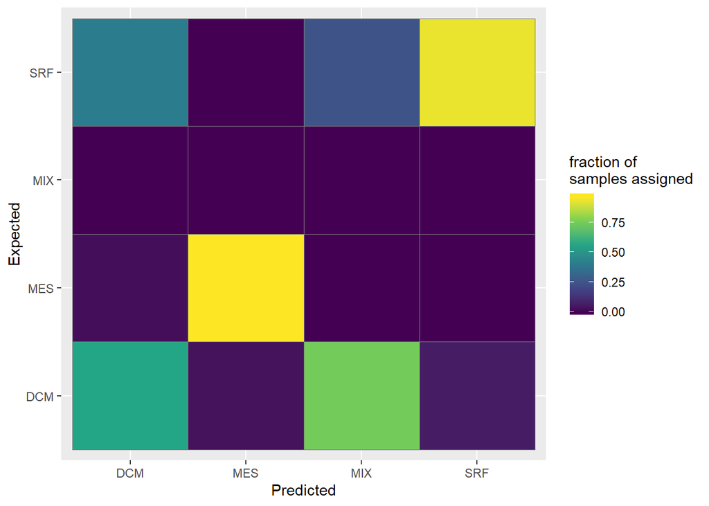

```r
require(tidyverse)
cfuzmat <- data.frame(RF_state_classify$confusion)
cfuzmat$Predicted <- row.names(cfuzmat)
tmp <- cfuzmat
tmp$class.error <- NULL
tmp$Predicted <- NULL
tmp2 <- sweep(tmp, 1, rowSums(tmp), '/')
tmp2$class.error <- tmp2$class.error
tmp2$Predicted <- row.names(tmp2)
cfuzplot <- gather(data = tmp2, key = Expected, value = value, c(1:4)) #change c(1:4) to the column numbers you would like to use
cfuzplot$Expected <- gsub("^X", "", cfuzplot$Expected)  ## removing the X from label name...
hm.1 <- ggplot(cfuzplot, aes(x=Predicted, y=Expected)) +
  geom_tile(aes(fill=value), color="grey50") +
  scale_fill_viridis_c() +
  labs(fill="fraction of\nsamples assigned")
hm.1
```

### which features are important?

We can see from the above confusion matrix that the classifier does a good job of assigning the correct samples to some sites but not to others. We might be interested in determining which ASVs are relevant to creating this model in the first place:

```r
RF_state_classify_imp <- as.data.frame( RF_state_classify$importance )
RF_state_classify_imp$features <- rownames( RF_state_classify_imp )
```

The values in the first few columns represent the decrease in prediction accuracy to the model when that particular ASV is removed from the classifier. Thus, the columns that match the metadata variable (`$Depth`) we were using as the predictive variable to traing the classifier with may demonstrate distinct accuracy prediction values for a given ASV.

## Running the model with permutations

Can incorporate significance information to RF model with permutations:

```r
require(rfUtilities)
RF_state_classify_sig <- rf.significance( x=RF_state_classify ,
                                          xdata=t_otu[,1:(ncol(t_otu)-1)] ,
                                          nperm=100 , ntree=501 )

RF_state_classify_sig
```

```
## Number of permutations:  100
## p-value:  0
## Model signifiant at p = 0
##   Model OOB error:  0.2158273
##   Random OOB error:  0.6115108
##   min random global error: 0.5035971
##   max random global error:  0.6834532
##   min random within class error: NA
##   max random within class error:  NA
```

Note that the model OOB error rate remains around the same 19.42% we observed in a single run.

## Running the model with “leave out” and permutations

```r
require(caret)
fit_control <- trainControl( method = "LOOCV" )   ## method is "Leave One Out Cross Validation"
RF_state_classify_loo <- train( t_otu[,1:(ncol(t_otu)-1)] ,
                                 y=t_otu[, ncol(t_otu)] ,
                                 method="rf", ntree=501 , tuneGrid=data.frame( mtry=25 ) ,
                                 trControl=fit_control )
```

To assess results:

```r
RF_state_classify_loo$results
```

```
##   mtry  Accuracy     Kappa
## 1   25 0.8273381 0.7274064
```

## Running the model with repeated k-fold cross-validation

This method will take the entire dataset and split it into two groups: one subset is used to train the model, and the remaining subset not used in training is used to test the classifer. This process is repeated k-times, with each iteration having our dataset being shuffled so that the subset of data used to train and test are different with each iteration.

```r
require(caret)
#split the data
set.seed(998)
# define training control
train_control <- trainControl(method="repeatedcv", number=5, repeats=10)
# train the model
model <- train(Depth ~ ., data = t_otu, trControl=train_control, method="rf", importance=TRUE)

# summarize results
print(model)
```

```
## Random Forest
##
##  139 samples
## 3023 predictors
##    4 classes: 'DCM', 'MES', 'MIX', 'SRF'
##
## No pre-processing
## Resampling: Cross-Validated (5 fold, repeated 10 times)
## Summary of sample sizes: 111, 111, 111, 111, 112, 111, ...
## Resampling results across tuning parameters:
##
##   mtry  Accuracy   Kappa
##      2  0.7634354  0.6268642
##     77  0.8169758  0.7117360
##   3023  0.8063108  0.6947295
##
## Accuracy was used to select the optimal model using the largest value.
## The final value used for the model was mtry = 77.
```

Obtaining the “imporatance” for each ASV to the model

```r
model_imp <- data.frame(varImp(model)$importance)
model_imp$taxa <- row.names(model_imp)
mi_plotdat <- gather(data = model_imp,
                     key = State,
                     value = Importance,
                     c(1:4)) #change c(1:4) for the number of columns of categories you have in your tmp file
```

Plot the Importance values associated with each ASV per metadata group.

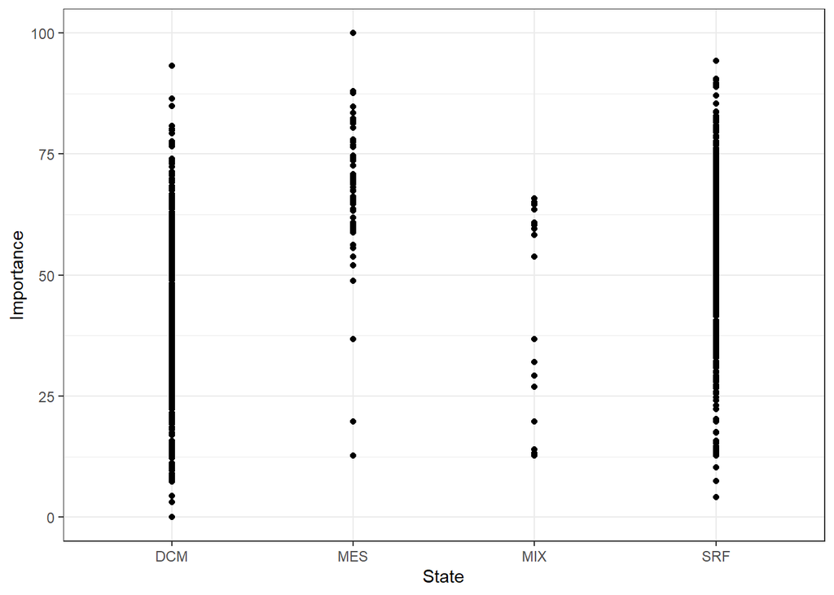

```r
ggplot(mi_plotdat, aes(x=State, y=Importance, label=taxa)) +
  geom_point() +
  theme_bw()
```

## misc

more resources for classifiers: http://topepo.github.io/caret/pre-processing.html https://www.stat.berkeley.edu/~breiman/RandomForests/cc_home.htm https://machinelearningmastery.com/k-fold-cross-validation/ https://cran.r-project.org/web/packages/caret/caret.pdf https://github.com/LangilleLab/microbiome_helper/wiki/Random-Forest-Tutorial

# Summary of analysis

MIX looks a lot like DCM and SRF. This is likely due to low sample size from MIX. Use the code below to see what the random forest analysis looks like with MIX removed.

# Re-do analysis without MIX layer

Use original datafiles from first chunk:

```r
require(tidyverse)
require(phyloseq)
otu.m <- as.data.frame(otutable_raw)
otu.m<-subset(otu.m, select=-c(X1)) #if there are more columns that are non-numeric (i.e. taxonomy) add in to the -c(). For example, if you have a column named taxonomy select=-c(X1, taxonomy).
row.names(otu.m) <- otutable_raw$X1

#add depth to the file
#upload mapping file

#what tara samples have MIX as depth?
MIX <- subset(map, Depth=="MIX")
MIX
```

```
## # A tibble: 4 x 4
##   SampleID            Depth Size_fraction Province
##   <chr>               <fct> <fct>         <fct>
## 1 TARA_123_MIX_0.22-3 MIX   0.22-3        South Pacific
## 2 TARA_124_MIX_0.22-3 MIX   0.22-3        South Pacific
## 3 TARA_125_MIX_0.22-3 MIX   0.22-3        South Pacific
## 4 TARA_152_MIX_0.22-3 MIX   0.22-3        North Atlantic
```

```r
#Remove columns with the sample IDs identified in MIX
otu.m <- otu.m[ ,-c(58,60,62,95)]
map.m <- map[-c(58,60,62,95),]

otu.m <- otu_table(otu.m, taxa_are_rows = T)

names(map.m)[1] <- 'SampleID'
row.names(map.m) <- map.m$SampleID
map.m[2:4] <- lapply(map.m[2:4] , factor) #change to columns where your factors are
map2.m <- data.frame(map.m)
meta.m <- sample_data(map.m)

## import as phyloseq object (If you already have a phyloseq object, you can start from here.)
ps.m <- phyloseq(otu.m, taxonomy, meta.m)
```

## Filtering and normalizing considerations

Authors of the tutorial document multiple approaches to both taxa filtering and read abundance normalization. Note that to incorporate those functions described one would need to operate on the `otu` and `meta` objects in the workflow, not the `ps` phyloseq object. Because we’ve imported our data as a Phyloseq object we’ll use the functions already written for that program to filter and transform these data.

```r
## Remove taxa not seen more than 3 times in at least 20% of the samples
ps2.m = filter_taxa(ps.m, function(x) sum(x > 3) > (0.2*length(x)), TRUE)

## saninity check: did we drop a lot of samples and/or taxa?
nsamples(ps2.m) ## nope
```

```
## [1] 135
```

```r
ntaxa(ps2.m)    ## yep.
```

```
## [1] 2958
```

```r
## filter original `otu` object to retain only those taxa that pass filter
otu2.m <- otu.m[taxa_names(ps2.m),]   ## this is the object we'll use for RF classifying
```

## Running the model - no permutations

Transforming our ASV table and metadata into a single object. First, transpose the `otu` table, then append whichever metadata you want to run the classifier with. In this example, we’ll use the metadata column `$Depth` - the depth the samples were obtained:

```r
t_otu.m <- data.frame(t(otu2.m))  ## update the ASV table of interest given filtering cosiderations above
t_otu.m$Depth <- map2.m[rownames(t_otu.m), "Depth"]
```

Set seed, then train the classifier:

```r
require(randomForest)
set.seed(151)
RF_state_classify <- randomForest( x=t_otu.m[,1:(ncol(t_otu.m)-1)] ,
                                   y=t_otu.m[ , ncol(t_otu.m)] ,
                                   ntree=501, importance=TRUE, proximities=TRUE )
```

Summaries of the classifier. Two main points to take note of in the summary: 1) the OOB (out-of-bag) estimate is an indication of the prediction error of the model 2) the Confusion matrix displays where predictions were and were not correct

```r
RF_state_classify
```

```
##
## Call:
##  randomForest(x = t_otu.m[, 1:(ncol(t_otu.m) - 1)], y = t_otu.m[,      ncol(t_otu.m)], ntree = 501, importance = TRUE, proximities = TRUE)
##                Type of random forest: classification
##                      Number of trees: 501
## No. of variables tried at each split: 54
##
##         OOB estimate of  error rate: 14.81%
## Confusion matrix:
##     DCM MES SRF class.error
## DCM  26   1  15  0.38095238
## MES   0  30   0  0.00000000
## SRF   4   0  59  0.06349206
```

We can plot this confusion matrix as a heatmap too:

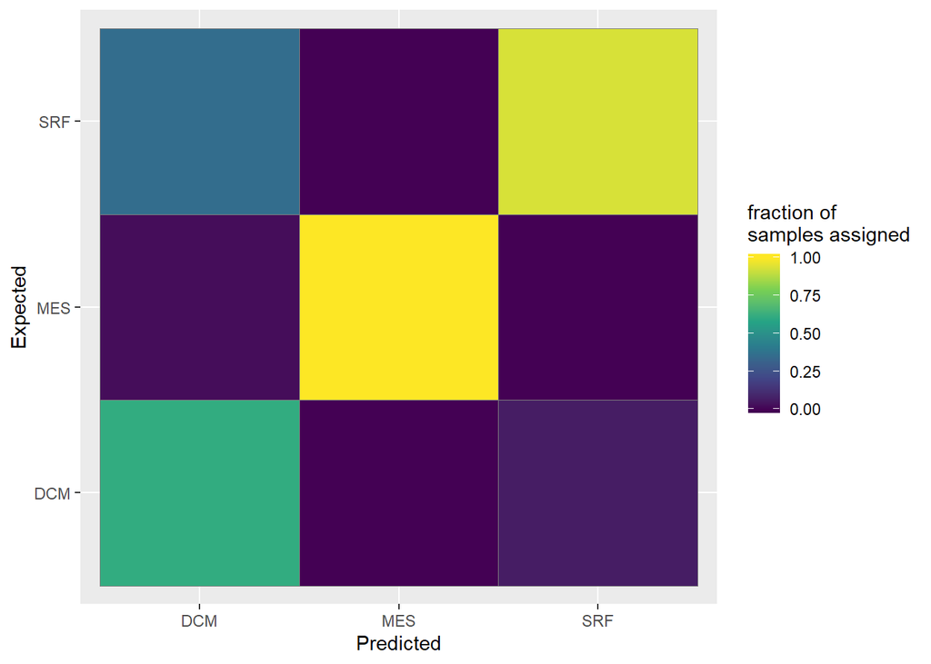

```r
require(tidyverse)
require(ggplot2)
cfuzmat.m <- data.frame(RF_state_classify$confusion)
cfuzmat.m$Predicted <- row.names(cfuzmat.m)
tmp.m <- cfuzmat.m
tmp.m$class.error <- NULL
tmp.m$Predicted <- NULL
tmp2.m <- sweep(tmp.m, 1, rowSums(tmp.m), '/')
tmp2.m$class.error <- tmp2.m$class.error
tmp2.m$Predicted <- row.names(tmp2.m)
cfuzplot.m <- gather(data = tmp2.m, key = Expected, value = value, c(1:3)) #change c(1:4) to the column numbers you would like to use
cfuzplot.m$Expected <- gsub("^X", "", cfuzplot.m$Expected)  ## removing the X from label name...
hm.2 <- ggplot(cfuzplot.m, aes(x=Predicted, y=Expected)) +
  geom_tile(aes(fill=value), color="grey50") +
  scale_fill_viridis_c() +
  labs(fill="fraction of\nsamples assigned")
hm.2
```

### which features are important?

We can see from the above confusion matrix that the classifier does a good job of assigning the correct samples to some sites but not to others. We might be interested in determining which ASVs are relevant to creating this model in the first place:

```r
RF_state_classify_imp <- as.data.frame( RF_state_classify$importance )
RF_state_classify_imp$features <- rownames( RF_state_classify_imp )
```

The values in the first few columns represent the decrease in prediction accuracy to the model when that particular ASV is removed from the classifier. Thus, the columns that match the metadata variable (`$Depth`) we were using as the predictive variable to traing the classifier with may demonstrate distinct accuracy prediction values for a given ASV.

## Running the model with permutations

Can incorporate significance information to RF model with permutations:

```r
require(rfUtilities)
RF_state_classify_sig <- rf.significance( x=RF_state_classify ,
                                          xdata=t_otu.m[,1:(ncol(t_otu.m)-1)] ,
                                          nperm=100 , ntree=501 )

RF_state_classify_sig
```

```
## Number of permutations:  100
## p-value:  0
## Model signifiant at p = 0
##   Model OOB error:  0.1481481
##   Random OOB error:  0.6
##   min random global error: 0.4962963
##   max random global error:  0.7037037
##   min random within class error: 0.8666667
##   max random within class error:  0.8666667
```

Note that the model OOB error rate remains around the same 14.8% we observed in a single run.

## Running the model with “leave out” and permutations

```r
require(caret)
fit_control <- trainControl( method = "LOOCV" )   ## method is "Leave One Out Cross Validation"
RF_state_classify_loo <- train( t_otu.m[,1:(ncol(t_otu.m)-1)] ,
                                 y=t_otu.m[, ncol(t_otu.m)] ,
                                 method="rf", ntree=501 , tuneGrid=data.frame( mtry=25 ) ,
                                 trControl=fit_control )
```

To assess results:

```r
RF_state_classify_loo$results
```

```
##   mtry  Accuracy     Kappa
## 1   25 0.8518519 0.7625956
```

## Running the model with repeated k-fold cross-validation

This method will take the entire dataset and split it into two groups: one subset is used to train the model, and the remaining subset not used in training is used to test the classifer. This process is repeated k-times, with each iteration having our dataset being shuffled so that the subset of data used to train and test are different with each iteration.

```r
require(caret)
#split the data
set.seed(998)
# define training control
train_control <- trainControl(method="repeatedcv", number=5, repeats=10)
# train the model
model <- train(Depth ~ ., data = t_otu.m, trControl=train_control, method="rf", importance=TRUE)

# summarize results
print(model)
```

```
## Random Forest
##
##  135 samples
## 2958 predictors
##    3 classes: 'DCM', 'MES', 'SRF'
##
## No pre-processing
## Resampling: Cross-Validated (5 fold, repeated 10 times)
## Summary of sample sizes: 108, 107, 108, 108, 109, 108, ...
## Resampling results across tuning parameters:
##
##   mtry  Accuracy   Kappa
##      2  0.7836569  0.6533541
##     76  0.8393610  0.7426677
##   2958  0.8340883  0.7343316
##
## Accuracy was used to select the optimal model using the largest value.
## The final value used for the model was mtry = 76.
```

Obtaining the “importance” for each ASV to the model

```r
model_imp <- data.frame(varImp(model)$importance)
model_imp$taxa <- row.names(model_imp)
mi_plotdat <- gather(data = model_imp,
                     key = State,
                     value = Importance,
                     c(1:3)) #change c(1:3) for the number of columns of categories you have in your tmp file
```

Plot the Importance values associated with each ASV per metadata group.

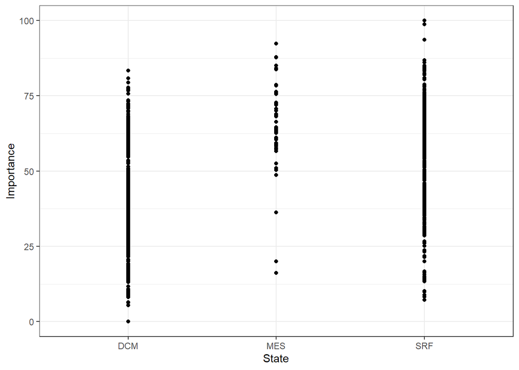

```r
ggplot(mi_plotdat, aes(x=State, y=Importance, label=taxa)) +
  geom_point() +
  theme_bw()
```

#Summary: The model did a good job of predicting the distinct groups.